# Différents tests sur les indices de diversité

# 2) Normalisation

TSS? Pour l’instant je laisse données brutes, il faudra voir quelle normalisation appliquer

```r
OTU_normalised <- matrix_otu
```

# 3) Diversité

## La richesse spécifique

```r
#richesse totale
RICHNESS<-apply(OTU_normalised, 1, function(x) length(which(x>=1)))
   #La richesse varie entre 209 et 316 selon les individus, avec une moyenne de 273 OTU différents détectés
range(RICHNESS)
```

```
## [1] 209 316
```

```r
mean(RICHNESS)
```

```
## [1] 272.8571
```

```r
#richesse en enlevant OTU apparus 1 fois
RICHNESS_1 <- apply(OTU_normalised, 1, function(x) length(which(x>1)))
#richesse en enlevant OTU apparus moins de 5 fois
RICHNESS_5 <- apply(OTU_normalised, 1, function(x) length(which(x>=5)))
#richesse en enlevant OTU apparus moins de 10 fois
RICHNESS_10 <- apply(OTU_normalised, 1, function(x) length(which(x>=10)))
```

On représente cette richesse spécifique :

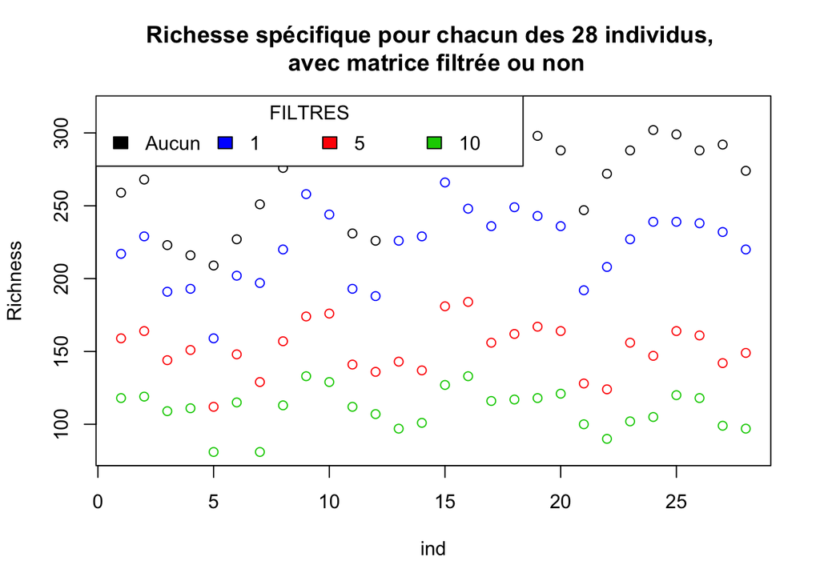

```r
plot(RICHNESS, ylim=range(RICHNESS, RICHNESS_10), ylab='Richness', xlab='ind',main="Richesse spécifique pour chacun des 28 individus, \n avec matrice filtrée ou non")
points(RICHNESS_1, col='blue')
points(RICHNESS_5, col='red')
points(RICHNESS_10, col='green3')
legend('topleft', legend=c("Aucun",1,5,10), fill = c('black','blue', "red", "green3"), title='FILTRES', horiz = T)
```

### Richesse et profondeur de séquençage

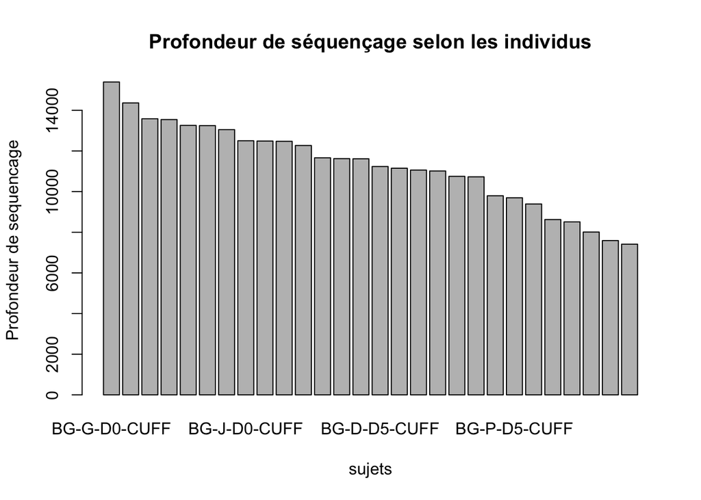

```r
barplot(sort(apply(matrix_otu, 1, sum),decreasing = TRUE), ylab='Profondeur de sequencage', xlab='sujets',main="Profondeur de séquençage selon les individus")
```

ON voit que selon les sujets, la profondeur de séquençage peut presque passer du simple au double ()

```r
profondeur_seq <- sort(apply(matrix_otu, 1, sum),decreasing = TRUE)
profondeur_seq[28]   #ind min : BG-I-D0-CTL, 7414 séquences
```

```
## BG-I-D0-CTL
##        7414
```

```r
profondeur_seq[1]    #ind max : BG-G-D0-CUFF, 15392 séquences
```

```
## BG-G-D0-CUFF
##        15392
```

#### Courbe de Raréfaction

On regarde si la profondeur de séquençage semble suffisante pour atteindre un plateau dans la richesse.

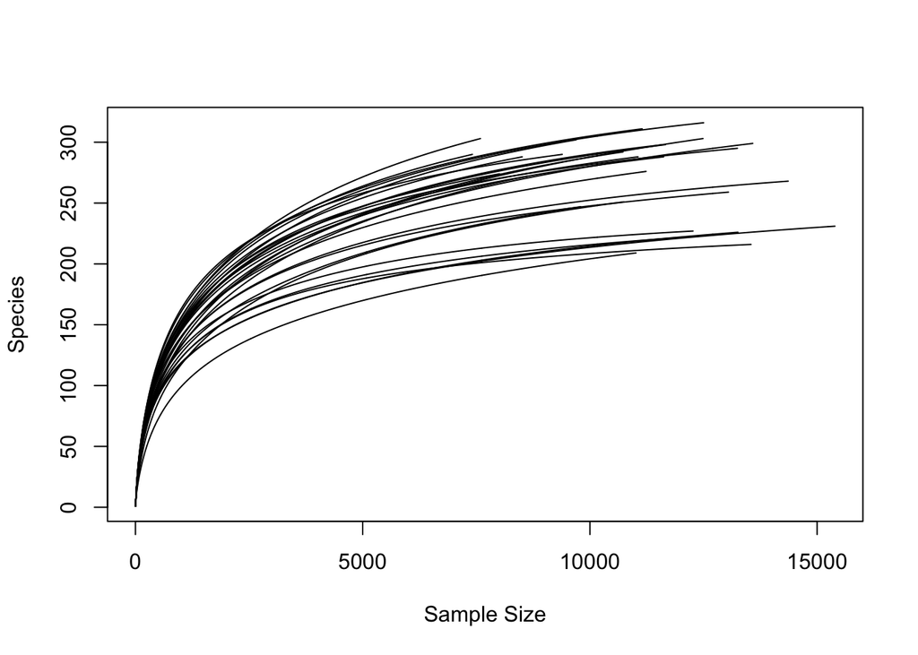

```r
rarecurve(matrix_otu, step=20,label=FALSE)
```

La courbe pour l’individu avec la profondeur de séquençage minimale (BG-I-D0-CTL ):

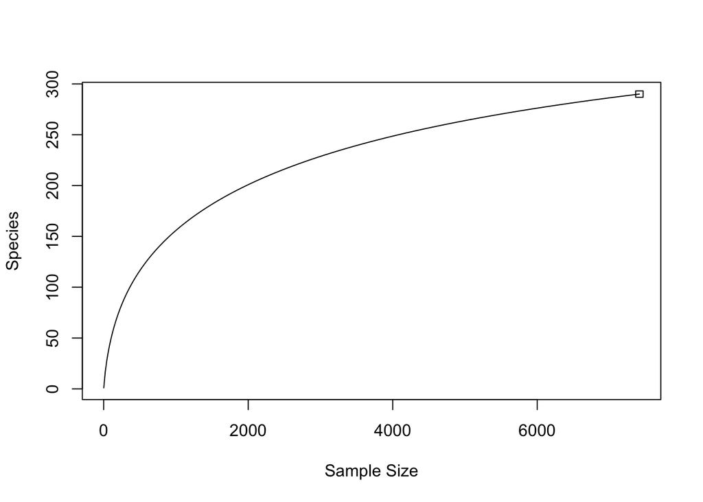

```r
rarecurve(matrix_otu["BG-I-D0-CTL",], step=20)
```

La courbe pour l’individu avec la profondeur de séquençage maximale (BG-G-D0-CUFF ):

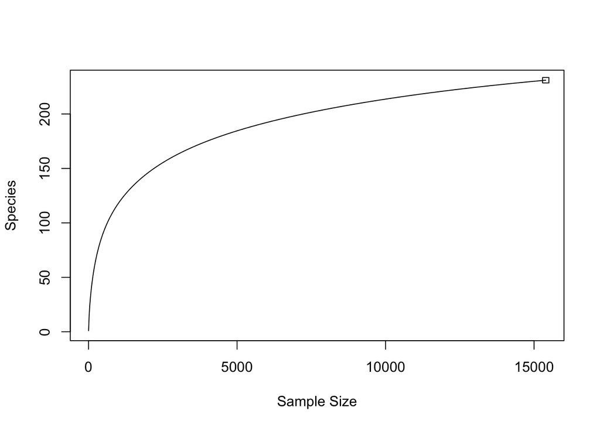

```r
rarecurve(matrix_otu["BG-G-D0-CUFF",], step=20)
```

Même s’il y a une convergence, peut-on vraiment parler de plateau ?

### Chao1

Le chao1 estime la richesse de la population en utilisant les OTU observés 1 ou 2 fois

Calculons le Chao1 pour les 28 sujets :

```r
CHAO1<-apply(matrix_otu, 1, function(x) chao1(x, taxa.row = T))
```

On compare ces valeurs avec la richesse spécifique :

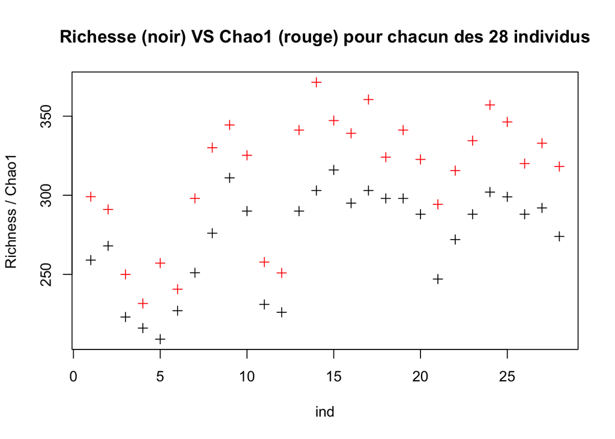

```r
plot(RICHNESS, ylab='Richness / Chao1', xlab='ind',main="Richesse (noir) VS Chao1 (rouge) pour chacun des 28 individus",pch=3,ylim=c(min(RICHNESS),max(CHAO1)))
points(CHAO1, col='red',pch=3)
```

Pour tous les individus, le Chao1 estime une richesse réelle supérieure à la richesse spécifique.

Se pose alors la question de la pertinence de l’indicateur Chao1: comme vu précédemment les données comportent énormément d’OTU détectés 1 ou 2 fois, mais c’est une chose “normale”, certains OTU sont rares. Ainsi on peut avoir deux réflexions:  
- Soit se dire que le Chao1 est quand même cohérent : la profondeur de séquençage n’a pas permis de détecter certains OTU rares => la courbe de raréfaction reste ambigue sur ce point.  
- Soit se dire que de toutes façons ces OTU (hypothétiques) très rares ne sont pas essentiels à l’analyse, et que le Chao1 crée un biais inutile.

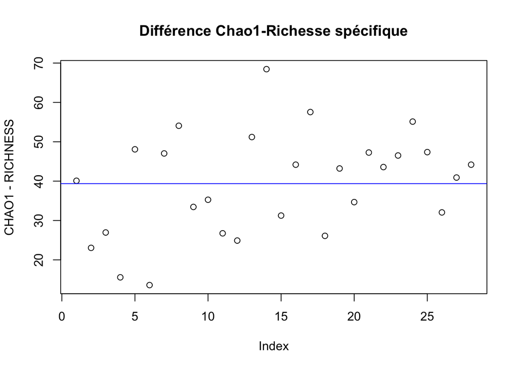

```r
plot(CHAO1-RICHNESS, main="Différence Chao1-Richesse spécifique")
abline(h=mean(CHAO1-RICHNESS),col="blue")
```

En moyenne, le chao1 estime que la vraie richesse est supérieure de 40 OTU à la richesse spécifique.

On construit une fonction qui va permettre de regarder l’évolution du Chao1 (comparé à la richesse spécifique) pour un individu choisi. On peut choisir un éventuel filtre :  
- si le filtre_inf est laissé à 0 et le filtre_sup laissé à max(ind) (valeurs par défaut), ce sont l’ensemble des OTU détectés pour l’indiv qui sont conservés.  
La fonction renvoie un dataframe (pour l’individu concerné) avec 3 colonnes: la profondeur de séquencage, l’évolution de la richesse spécifique et l’évolution du chao1.

```r
RARE_CURVE_RICHNESS_CHAO <- function(indiv,filtre_inf = 0,filtre_sup = max(ind)){
      #on choisit un individu
      ind= matrix_otu[indiv,]
      ind= t(ind[which(ind>filtre_inf & ind<=filtre_sup)])

      # On veut passer d'un vecteur de comptage aux données de séquençage d'origine
      # on va donc répéter le nom des OTU autant de fois qu'ils ont été comptés et en faire un vecteur
      sequencage=NULL
      for (i in 1:length(ind)){
        new=rep(rownames(ind)[i], ind[i])
        sequencage=c(sequencage,new)
      }

      # Puis on va reconstituer la courbe de rarefaction "à la main", avec des tirages aléatoires dans le vecteur sequencage
      # et en même temps le chao1
      richness=chao=NULL
      for (j in seq(1,length(sequencage), by=100)){
        u=sample(as.factor(sequencage), size=j)
        richness=c(richness,length(unique(u)))
        chao=c(chao,chao1(table(u)))
      }

      # On crée un data frame pour associer les bonnes profondeurs de séquencages aux valeurs calculées
      rare_curves=data.frame("deep"=seq(1,length(sequencage), by=100),"Richesse"=richness,"Chao"=chao)

      #on retourne le résultat
      return(rare_curves)

}
```

On peut maintenant tracer les courbes qui nous intéressent :

##### Individu avec la profondeur de séquençage la plus grande: “BG-G-D0-CUFF”

- **Premier cas : tous les OTU**

```r
rare_curves_all <- RARE_CURVE_RICHNESS_CHAO(indiv = "BG-G-D0-CUFF")
plot(x=rare_curves_all$deep,y=rare_curves_all$Richesse , ylim=c(0,max(rare_curves_all$Chao)), main="Evolution richesse spécifique (noir) et Chao1 (rouge) \n si tous les OTU sont conservés " )
points(x=rare_curves_all$deep,y=rare_curves_all$Chao, col='red')
```

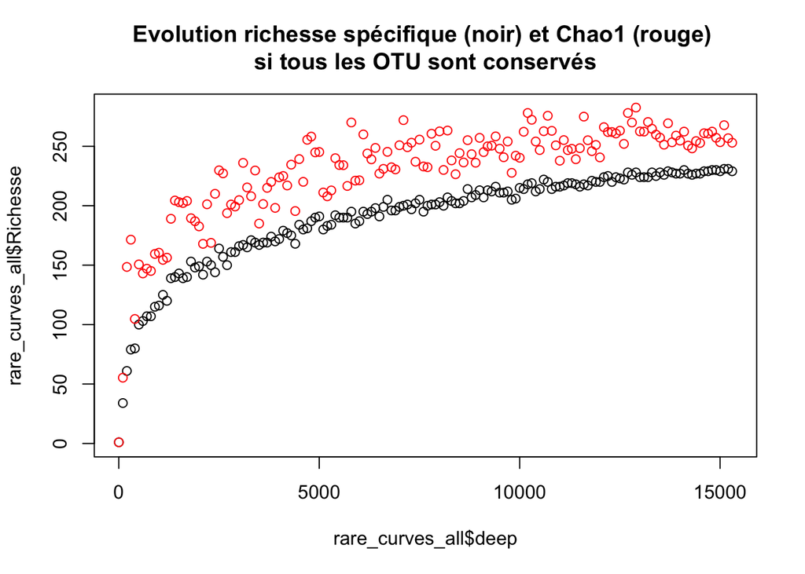

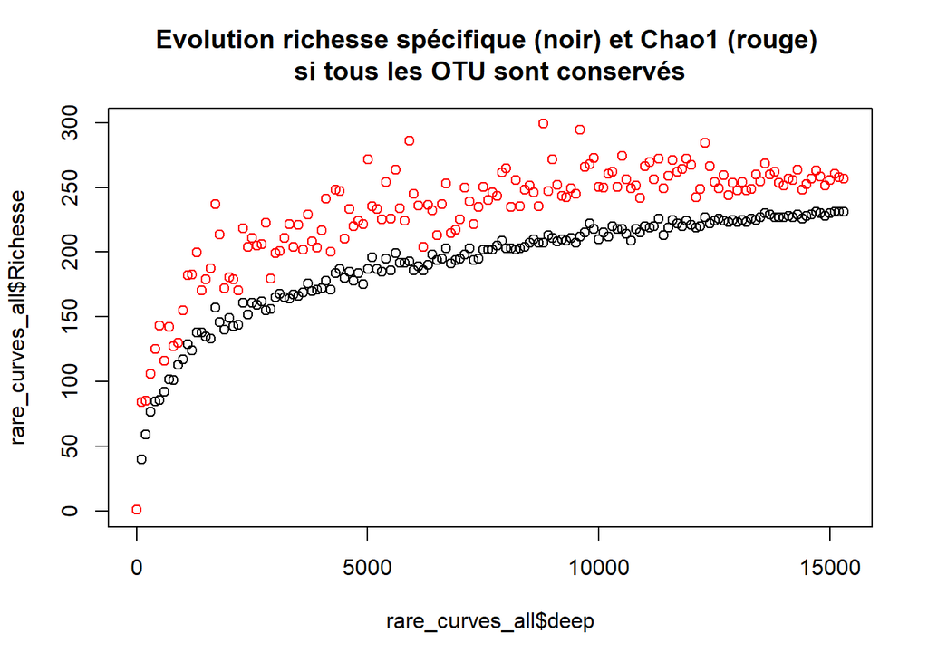

On retrouve en noir la courbe de raréfaction et en rouge l’évolution du Chao1.

- **Deuxième cas : en enlevant les OTU apparus une fois**

```r
rare_curves <- RARE_CURVE_RICHNESS_CHAO(indiv = "BG-G-D0-CUFF",filtre_inf = 1)
plot(x=rare_curves$deep,y=rare_curves$Richesse , ylim=c(0,max(rare_curves$Chao)), main="Evolution richesse spécifique (noir) et Chao1 (rouge) \n si les OTU apparus 1 fois sont supprimés " )
points(x=rare_curves$deep,y=rare_curves$Chao, col='red')
```

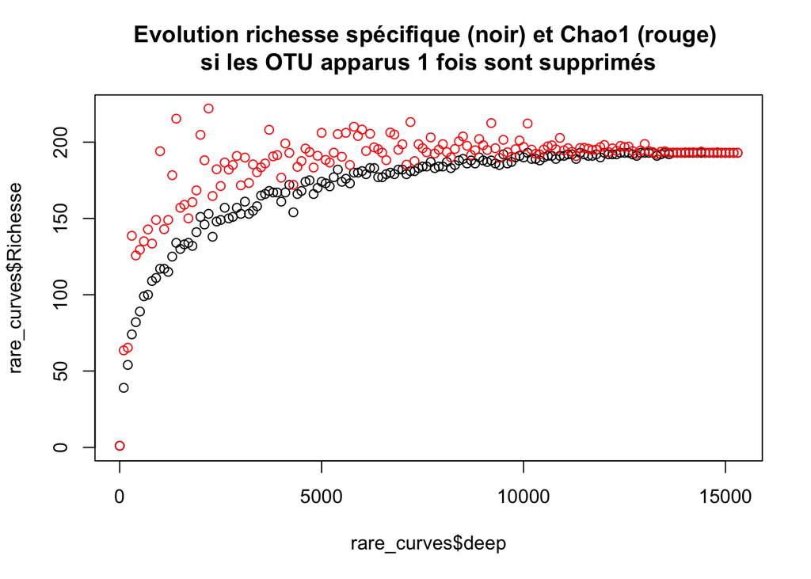

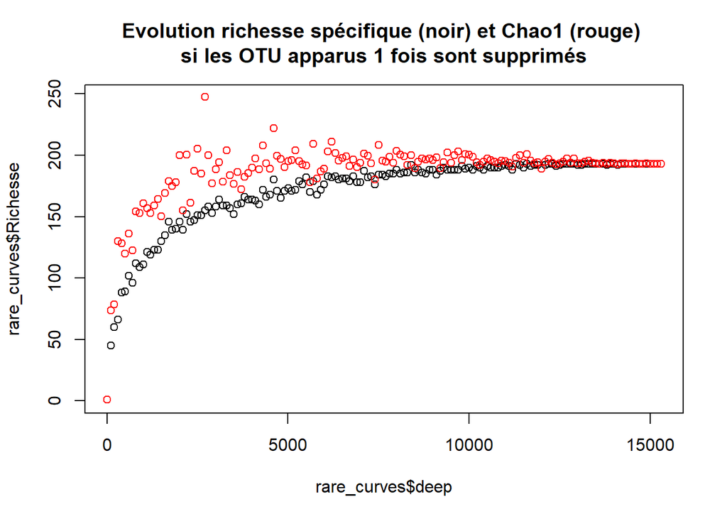

Concernant la courbe de rarefaction en noire : le plateau semble plus net, la richesse spécifique se stabilise plus nettement. Le Chao1 rejoint la richesse spécifique quand la profondeur de séquencage arrive autour de 10 000!

- **Troisième cas : en enlevant les OTU apparus 5 fois ou moins**

```r
rare_curves <- RARE_CURVE_RICHNESS_CHAO(indiv = "BG-G-D0-CUFF",filtre_inf = 5)
plot(x=rare_curves$deep,y=rare_curves$Richesse , ylim=c(0,max(rare_curves$Chao)), main="Evolution richesse spécifique (noir) et Chao1 (rouge) \n si les OTU apparus moins de 5 fois sont supprimés " )
points(x=rare_curves$deep,y=rare_curves$Chao, col='red')
```

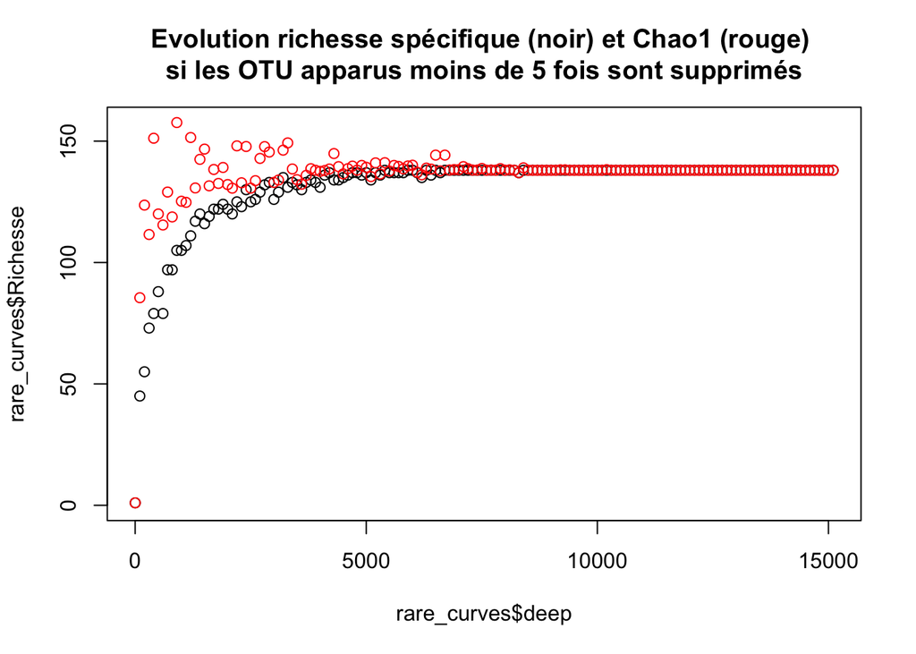

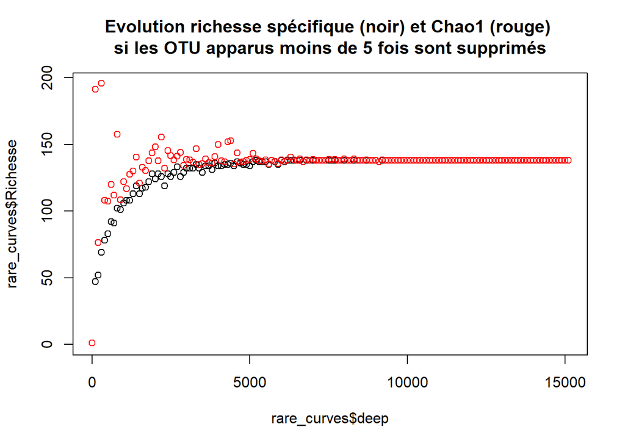

Le Chao1 rejoint la richesse spécifique quand la profondeur de séquencage arrive autour de 5 000. Pour les deux indices, le plateau est tès vite atteint la convergence est nette.

- **Quatrième cas : en enlevant les OTU apparus plus de 50 fois** Remarque : logiquement cela fait baisser énormément la profondeur de séquencage donc pas une bonne idée

```r
rare_curves <- RARE_CURVE_RICHNESS_CHAO(indiv = "BG-G-D0-CUFF",filtre_sup = 50)
plot(x=rare_curves$deep,y=rare_curves$Richesse , ylim=c(0,max(rare_curves$Chao)), main="Evolution richesse spécifique (noir) et Chao1 (rouge) \n si les OTU apparus plus de 50 fois sont supprimés " )
points(x=rare_curves$deep,y=rare_curves$Chao, col='red')
```

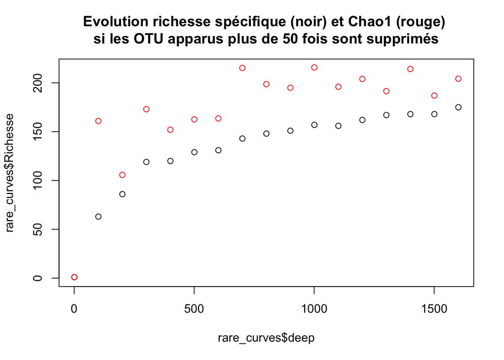

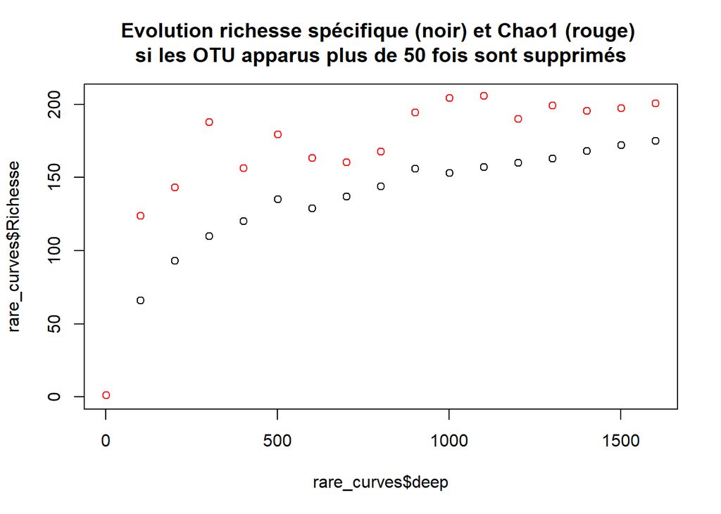

##### Individu avec la profondeur de séquençage la plus petite: “BG-I-D0-CTL”

- **Premier cas : tous les OTU**

```r
rare_curves_all <- RARE_CURVE_RICHNESS_CHAO(indiv = "BG-I-D0-CTL")
plot(x=rare_curves_all$deep,y=rare_curves_all$Richesse , ylim=c(0,max(rare_curves_all$Chao)), main="Evolution richesse spécifique (noir) et Chao1 (rouge) \n si tous les OTU sont conservés " )
points(x=rare_curves_all$deep,y=rare_curves_all$Chao, col='red')
```

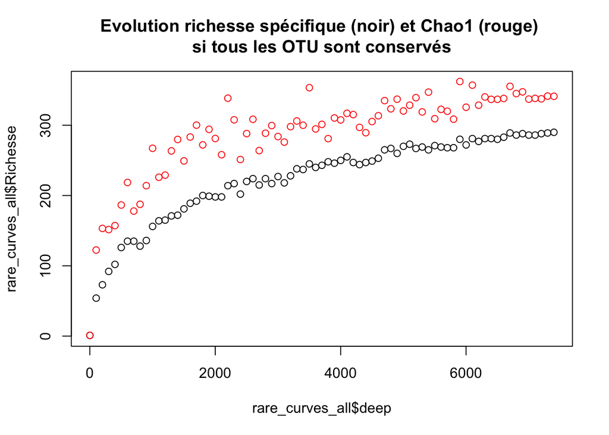

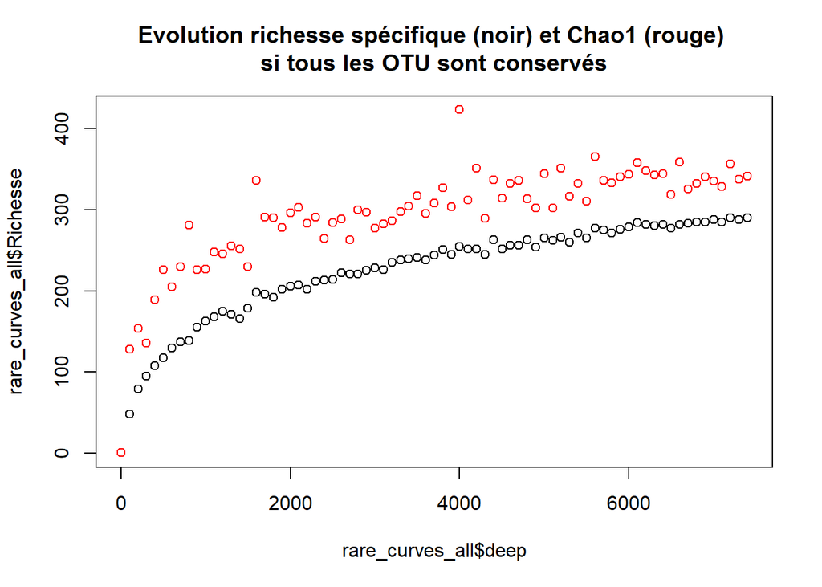

On retrouve en noir la courbe de raréfaction et en rouge l’évolution du Chao1.

- **Deuxième cas : en enlevant les OTU apparus une fois**

```r
rare_curves <- RARE_CURVE_RICHNESS_CHAO(indiv = "BG-I-D0-CTL",filtre_inf = 1)
plot(x=rare_curves$deep,y=rare_curves$Richesse , ylim=c(0,max(rare_curves$Chao)), main="Evolution richesse spécifique (noir) et Chao1 (rouge) \n si les OTU apparus 1 fois sont supprimés " )
points(x=rare_curves$deep,y=rare_curves$Chao, col='red')
```

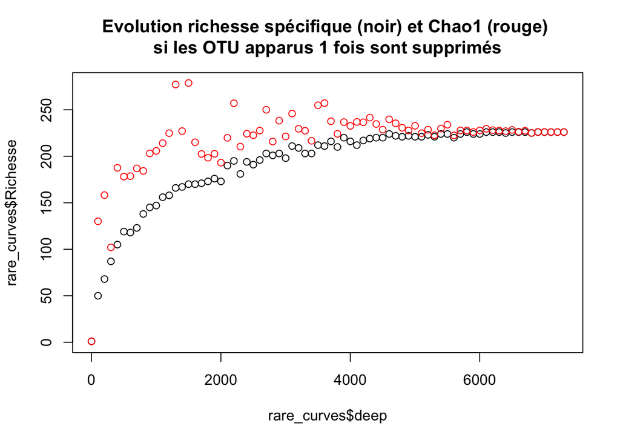

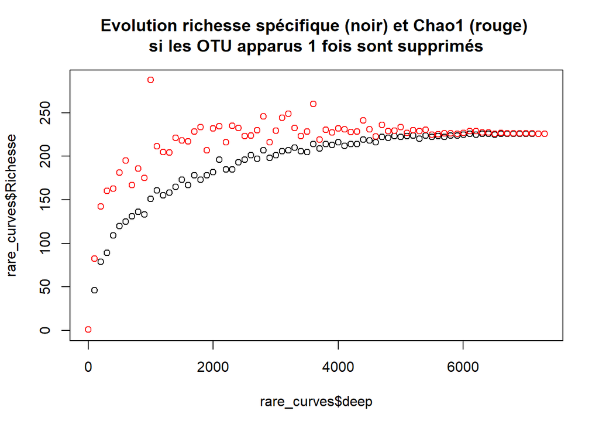

Concernant la courbe de rarefaction en noire : le plateau semble plus net, la richesse spécifique se stabilise plus nettement. Le Chao1 rejoint la richesse spécifique quand la profondeur de séquencage arrive autour de 6 000!

- **Troisième cas : en enlevant les OTU apparus 5 fois ou moins**

```r
rare_curves <- RARE_CURVE_RICHNESS_CHAO(indiv = "BG-I-D0-CTL",filtre_inf = 5)
plot(x=rare_curves$deep,y=rare_curves$Richesse , ylim=c(0,max(rare_curves$Chao)), main="Evolution richesse spécifique (noir) et Chao1 (rouge) \n si les OTU apparus moins de 5 fois sont supprimés " )
points(x=rare_curves$deep,y=rare_curves$Chao, col='red')
```

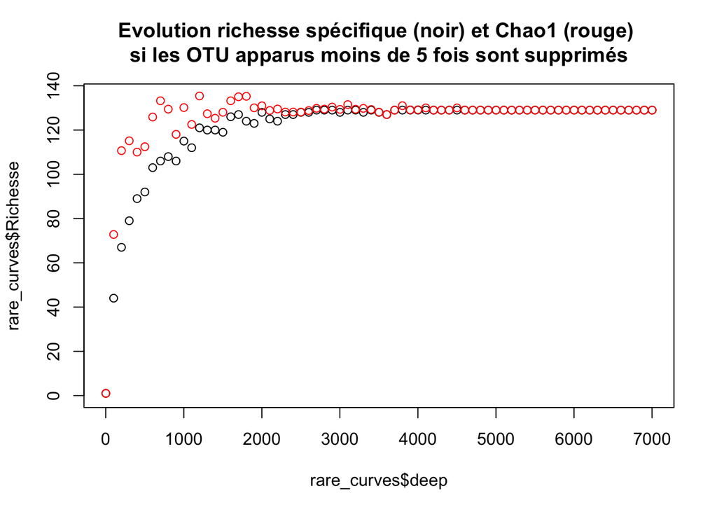

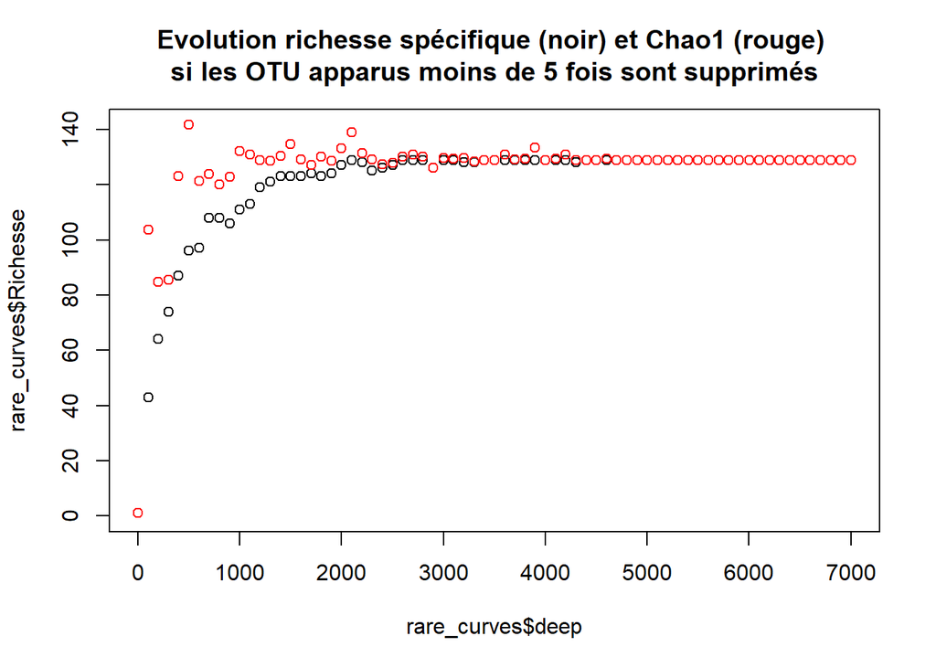

Le Chao1 rejoint la richesse spécifique quand la profondeur de séquencage arrive autour de 3 500. Pour les deux indices, le plateau est très vite atteint la convergence est nette.

- **Quatrième cas : en enlevant les OTU apparus plus de 50 fois** Remarque : logiquement cela fait baisser énormément la profondeur de séquencage donc pas une bonne idée

```r
rare_curves <- RARE_CURVE_RICHNESS_CHAO(indiv = "BG-I-D0-CTL",filtre_sup = 50)
plot(x=rare_curves$deep,y=rare_curves$Richesse , ylim=c(0,max(rare_curves$Chao)), main="Evolution richesse spécifique (noir) et Chao1 (rouge) \n si les OTU apparus plus de 50 fois sont supprimés " )
points(x=rare_curves$deep,y=rare_curves$Chao, col='red')
```

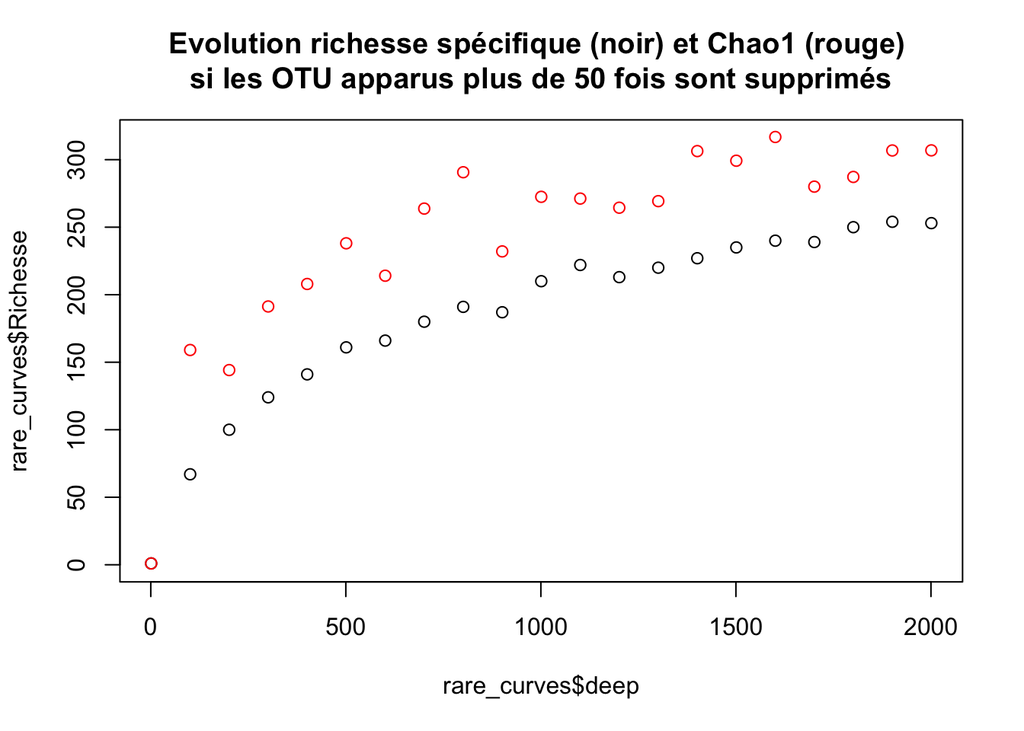

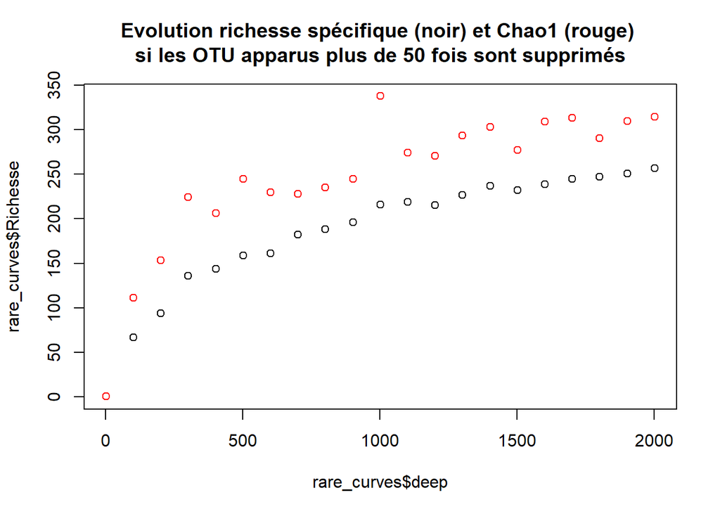

## Indice de Simpson

Interprétation : La probabilité que deux bactéries tirées au hasard dans l’échantillon soient d’espèces différentes:  
- Quand simpson tend vers 0 : une espèce domine les autres, peu de diversification  
- Quand simpson tend vers 1 : grande diversification

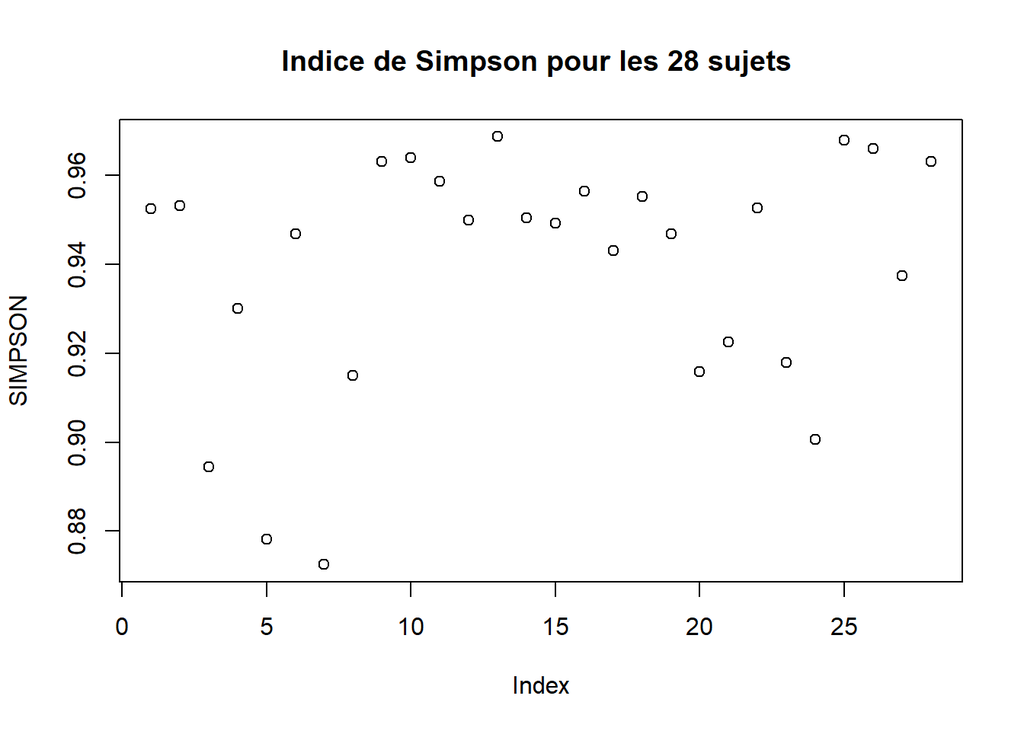

```r
#Simpson
SIMPSON=diversity(matrix_otu, index='simpson')
plot(SIMPSON,main="Indice de Simpson pour les 28 sujets ")
```

Globalement, indices de SIMPSON élevés (proches de 1) : proba élevée de tomber sur deux bactéries différentes.

Est-ce que les sujets avec les indices un peu plus faible sont ceux avec la profondeur de séquençage la plus faible ? On peut regarder la corrélation entre la profondeur de séquençage et l’indice de SIMPSON:

**Lien avec la profondeur de séquençage**

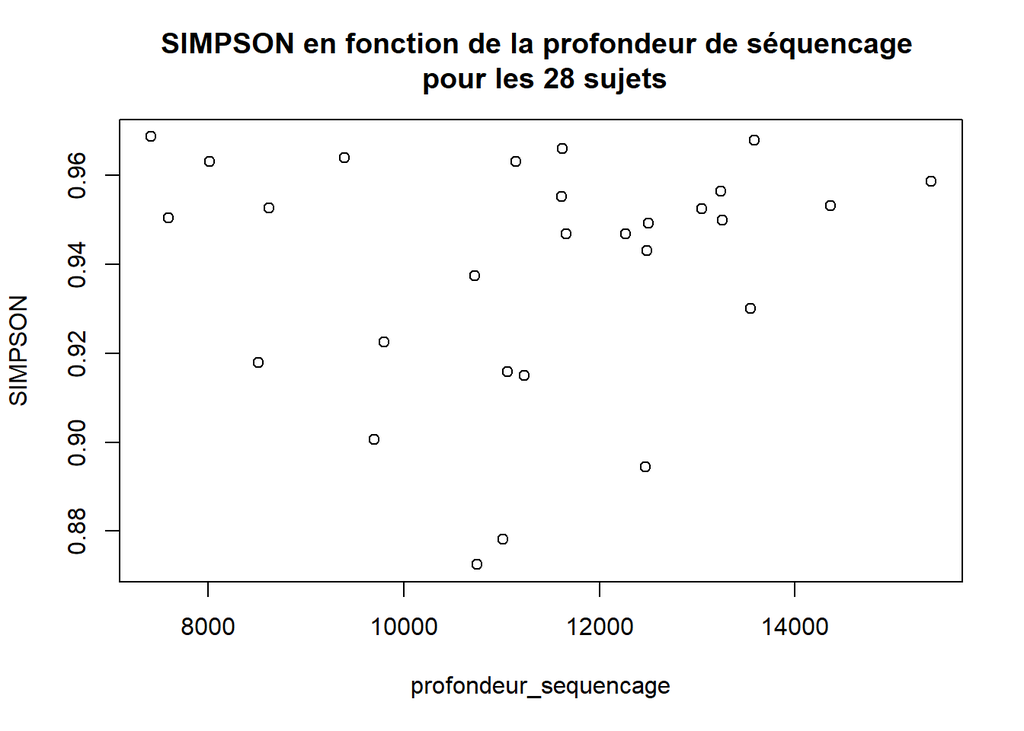

```r
profondeur_sequencage <- apply(matrix_otu, 1, sum)
plot(x=profondeur_sequencage,SIMPSON, main="SIMPSON en fonction de la profondeur de séquencage \n pour les 28 sujets")
```

```r
summary(lm(SIMPSON~profondeur_seq))
```

```
##
## Call:
## lm(formula = SIMPSON ~ profondeur_seq)
##
## Residuals:
##      Min       1Q   Median       3Q      Max
## -0.06210 -0.02039  0.01095  0.01963  0.03049
##
## Coefficients:
##                  Estimate Std. Error t value Pr(>|t|)
## (Intercept)     9.671e-01  2.874e-02  33.647   <2e-16 ***
## profondeur_seq -2.489e-06  2.506e-06  -0.993     0.33
## ---
## Signif. codes:  0 '***' 0.001 '**' 0.01 '*' 0.05 '.' 0.1 ' ' 1
##
## Residual standard error: 0.02704 on 26 degrees of freedom
## Multiple R-squared:  0.03655,    Adjusted R-squared:  -0.0005026
## F-statistic: 0.9864 on 1 and 26 DF,  p-value: 0.3298
```

Peut être car de toute façon la profondeur de séquencage est suffisamment élevée dans tous les cas.

**Lien avec la richesse**

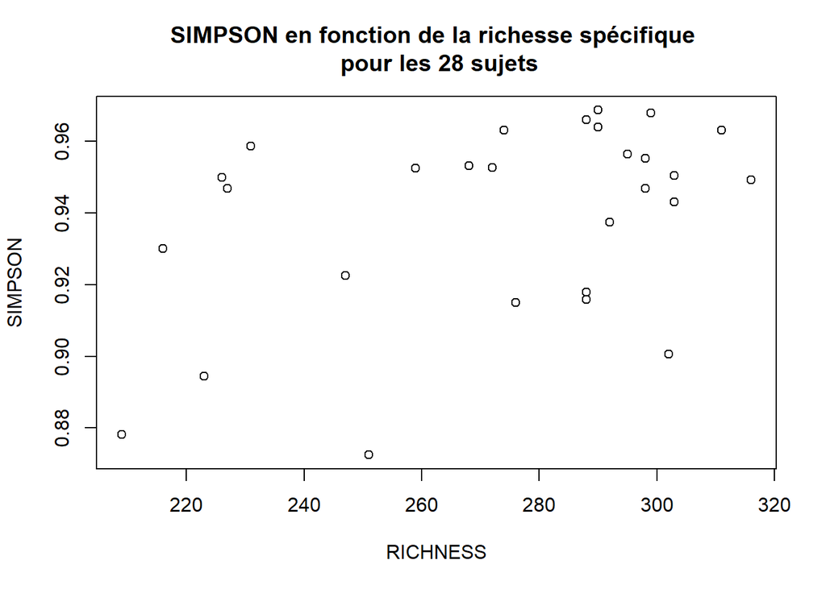

```r
plot(RICHNESS,SIMPSON, main="SIMPSON en fonction de la richesse spécifique \n pour les 28 sujets")
```

```r
summary(lm(SIMPSON~RICHNESS))
```

```
##
## Call:
## lm(formula = SIMPSON ~ RICHNESS)
##
## Residuals:
##       Min        1Q    Median        3Q       Max
## -0.058808 -0.012550  0.008546  0.019118  0.034363
##
## Coefficients:
##              Estimate Std. Error t value Pr(>|t|)
## (Intercept) 0.8431276  0.0417133  20.212   <2e-16 ***
## RICHNESS    0.0003513  0.0001519   2.313   0.0289 *
## ---
## Signif. codes:  0 '***' 0.001 '**' 0.01 '*' 0.05 '.' 0.1 ' ' 1
##
## Residual standard error: 0.02509 on 26 degrees of freedom
## Multiple R-squared:  0.1707, Adjusted R-squared:  0.1388
## F-statistic: 5.351 on 1 and 26 DF,  p-value: 0.02888
```

Cette fois on a une très légère corrélation positive.

**En faisant varier la taille des séquences**

```r
RARE_CURVE_SIMPSON <- function(indiv,filtre_inf = 0,filtre_sup = max(ind)){
      #on choisit un individu
      ind= matrix_otu[indiv,]
      ind= t(ind[which(ind>filtre_inf & ind<=filtre_sup)])

      # On veut passer d'un vecteur de comptage aux données de séquençage d'origine
      # on va donc répéter le nom des OTU autant de fois qu'ils ont été comptés et en faire un vecteur
      sequencage=NULL
      for (i in 1:length(ind)){
        new=rep(rownames(ind)[i], ind[i])
        sequencage=c(sequencage,new)
      }

      # Puis on regarde l'évolution de simpson selon la taille de la séquence
      simpson=NULL
      for (j in seq(1,length(sequencage), by=100)){
        u=sample(as.factor(sequencage), size=j)
        simpson=c(simpson,diversity(table(u), index='simpson'))
      }

      # On crée un data frame pour associer les bonnes profondeurs de séquencages aux valeurs calculées
      rare_curves=data.frame("deep"=seq(1,length(sequencage), by=100),"simpson"=simpson)

      #on retourne le résultat
      return(rare_curves)

}
```

- avec **aucun filtre** :

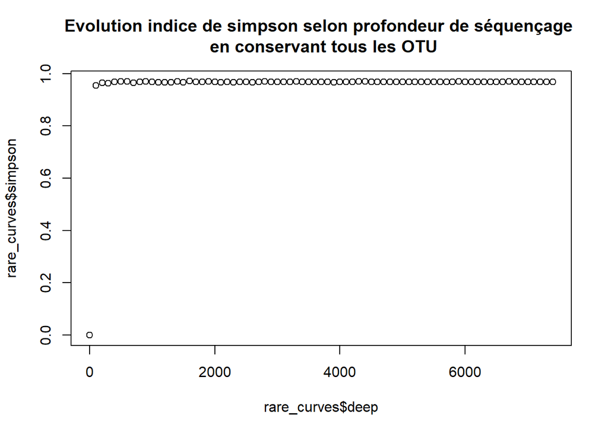

```r
rare_curves <- RARE_CURVE_SIMPSON(indiv = "BG-I-D0-CTL")
plot(x=rare_curves$deep,y=rare_curves$simpson , main="Evolution indice de simpson selon profondeur de séquençage \n en conservant tous les OTU" )
```

- en **enlevant les OTU apparus 1 fois** :

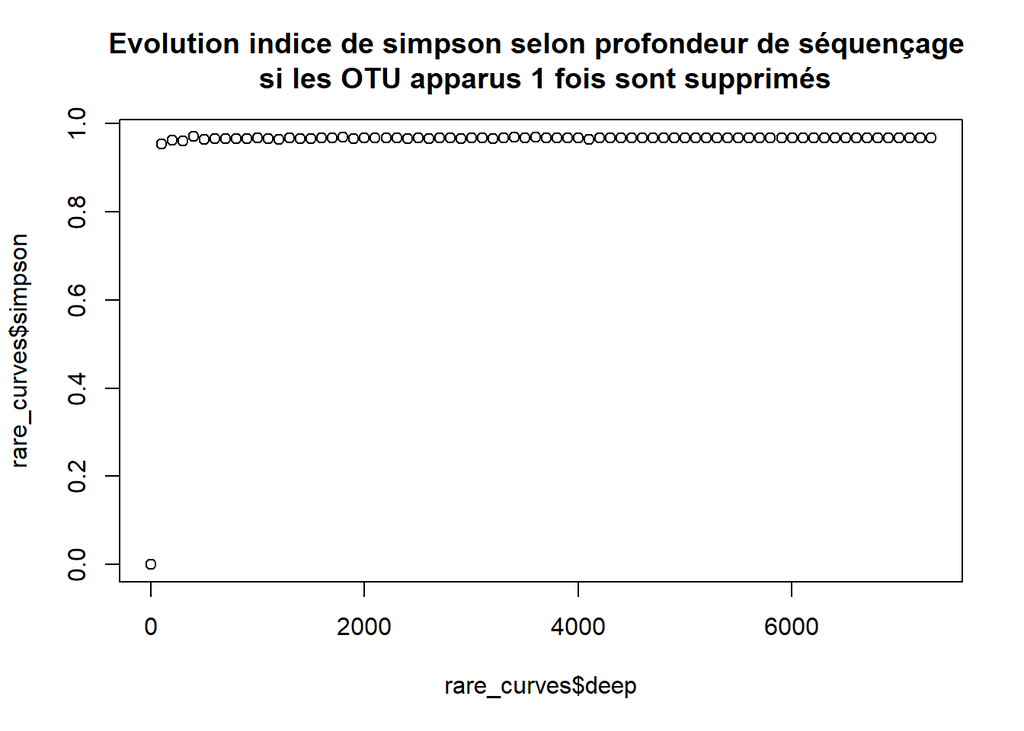

```r
rare_curves <- RARE_CURVE_SIMPSON(indiv = "BG-I-D0-CTL",filtre_inf = 1)
plot(x=rare_curves$deep,y=rare_curves$simpson , main="Evolution indice de simpson selon profondeur de séquençage \n si les OTU apparus 1 fois sont supprimés" )
```

- en **enlevant les OTU apparus moins de 5 fois** :

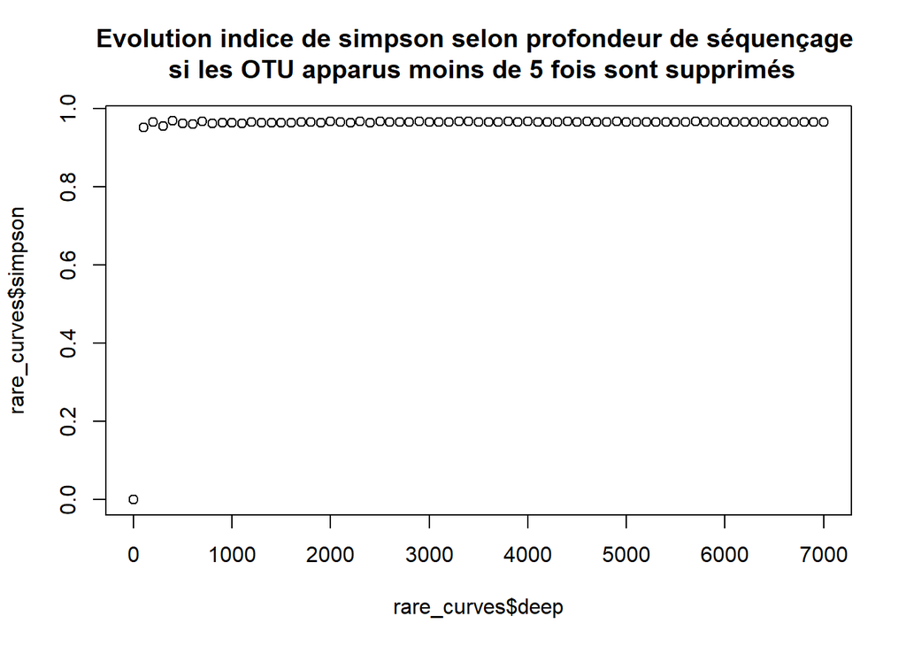

```r
rare_curves <- RARE_CURVE_SIMPSON(indiv = "BG-I-D0-CTL",filtre_inf=5)
plot(x=rare_curves$deep,y=rare_curves$simpson , main="Evolution indice de simpson selon profondeur de séquençage \n si les OTU apparus moins de 5 fois sont supprimés" )
```

Enlever les OTU apparus peu de fois n’impacte pas l’indice de SIMPSON, on a toujours une grande proba de tomber sur 2 OTU différents.

- en **enlevant les OTU apparus plus de 50 fois** :

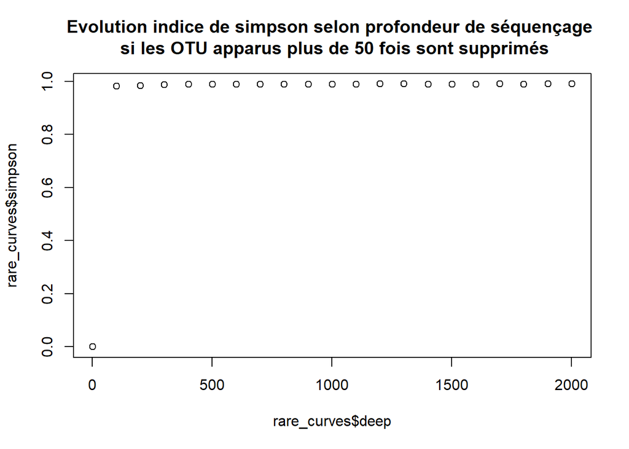

```r
rare_curves <- RARE_CURVE_SIMPSON(indiv = "BG-I-D0-CTL",filtre_sup=50)
plot(x=rare_curves$deep,y=rare_curves$simpson , main="Evolution indice de simpson selon profondeur de séquençage \n si les OTU apparus plus de 50 fois sont supprimés" )
```

Là encore l’indice de Simpson reste très élevé au bout de peu de séquencage